# 07_22_10차시험_조지헌

## 2020년도 07월 기준으로 '전년도'에 비해 그래프가 덜 상승된것으로 보아, 시계열 예측상 앞으로 날씨는 더 더워질 예정으로 예측된다.

```python
forecast
```

|  | ds | trend | yhat_lower | yhat_upper | trend_lower | trend_upper | additive_terms | additive_terms_lower | additive_terms_upper | daily | ... | weekly | weekly_lower | weekly_upper | yearly | yearly_lower | yearly_upper | multiplicative_terms | multiplicative_terms_lower | multiplicative_terms_upper | yhat |
| --- | --- | --- | --- | --- | --- | --- | --- | --- | --- | --- | --- | --- | --- | --- | --- | --- | --- | --- | --- | --- | --- |
| 0 | 1990-06-10 | 17.776116 | 17.956667 | 25.994437 | 17.776116 | 17.776116 | 4.194535 | 4.194535 | 4.194535 | -5.266321 | ... | 0.079655 | 0.079655 | 0.079655 | 9.381201 | 9.381201 | 9.381201 | 0.0 | 0.0 | 0.0 | 21.970651 |
| 1 | 1990-06-11 | 17.776227 | 17.976600 | 26.201740 | 17.776227 | 17.776227 | 4.302501 | 4.302501 | 4.302501 | -5.266321 | ... | 0.056505 | 0.056505 | 0.056505 | 9.512316 | 9.512316 | 9.512316 | 0.0 | 0.0 | 0.0 | 22.078728 |
| 2 | 1990-06-12 | 17.776339 | 18.274431 | 26.118214 | 17.776339 | 17.776339 | 4.272956 | 4.272956 | 4.272956 | -5.266321 | ... | -0.096859 | -0.096859 | -0.096859 | 9.636136 | 9.636136 | 9.636136 | 0.0 | 0.0 | 0.0 | 22.049295 |
| 3 | 1990-06-13 | 17.776451 | 18.241878 | 26.313168 | 17.776451 | 17.776451 | 4.378260 | 4.378260 | 4.378260 | -5.266321 | ... | -0.107885 | -0.107885 | -0.107885 | 9.752466 | 9.752466 | 9.752466 | 0.0 | 0.0 | 0.0 | 22.154711 |
| 4 | 1990-06-14 | 17.776562 | 18.102518 | 26.698967 | 17.776562 | 17.776562 | 4.563164 | 4.563164 | 4.563164 | -5.266321 | ... | -0.031722 | -0.031722 | -0.031722 | 9.861206 | 9.861206 | 9.861206 | 0.0 | 0.0 | 0.0 | 22.339726 |
| ... | ... | ... | ... | ... | ... | ... | ... | ... | ... | ... | ... | ... | ... | ... | ... | ... | ... | ... | ... | ... | ... |
| 11000 | 2020-07-22 | 18.896396 | 22.686873 | 30.831009 | 18.896396 | 18.896396 | 7.858078 | 7.858078 | 7.858078 | -5.266321 | ... | -0.107885 | -0.107885 | -0.107885 | 13.232283 | 13.232283 | 13.232283 | 0.0 | 0.0 | 0.0 | 26.754474 |
| 11001 | 2020-07-23 | 18.896660 | 22.995051 | 30.709151 | 18.896660 | 18.896660 | 8.068718 | 8.068718 | 8.068718 | -5.266321 | ... | -0.031722 | -0.031722 | -0.031722 | 13.366761 | 13.366761 | 13.366761 | 0.0 | 0.0 | 0.0 | 26.965378 |
| 11002 | 2020-07-24 | 18.896924 | 22.881578 | 31.256763 | 18.896924 | 18.896924 | 8.229428 | 8.229428 | 8.229428 | -5.266321 | ... | -0.000499 | -0.000499 | -0.000499 | 13.496248 | 13.496248 | 13.496248 | 0.0 | 0.0 | 0.0 | 27.126352 |
| 11003 | 2020-07-25 | 18.897188 | 23.800033 | 31.578794 | 18.897188 | 18.897188 | 8.454053 | 8.454053 | 8.454053 | -5.266321 | ... | 0.100804 | 0.100804 | 0.100804 | 13.619570 | 13.619570 | 13.619570 | 0.0 | 0.0 | 0.0 | 27.351241 |
| 11004 | 2020-07-26 | 18.897452 | 23.503259 | 31.559490 | 18.897452 | 18.897452 | 8.548920 | 8.548920 | 8.548920 | -5.266321 | ... | 0.079655 | 0.079655 | 0.079655 | 13.735586 | 13.735586 | 13.735586 | 0.0 | 0.0 | 0.0 | 27.446372 |

11005 rows × 22 columns

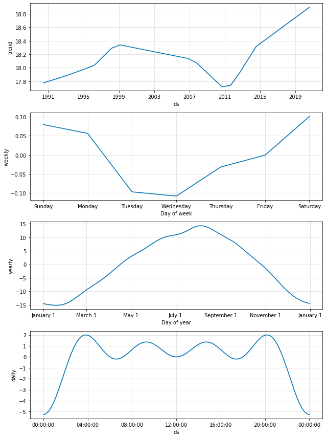

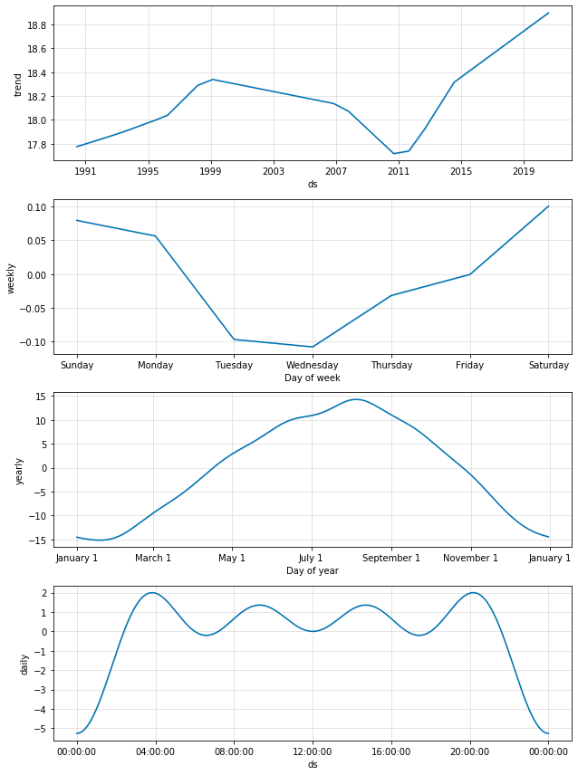

```python
m.plot_components(forecast) #그래프화 하여, 해당 데이터들의 지표를 그래프로 보여줌
```

```python
# yearly : forecast 모델은 7~9월 사이 온도가 가장 높다고 보여줌
```

## [2]. Matplotlib 의 pylot와 Scatter(산점도) 그리는 방법

```python
# pylot 은 matplotlib의 라이브러리로서, 데이터를 차트 위에서 시각화(가시화) 하는데 사용하는 라이브러리이다. + 넘파이와 짝꿍!

# import matplotlib.pylot as plt
#1. 직선 그래프 plot() 으로 표현 가능 x,y 축 데이터가 필요함
# plt.plot(p[1,2,3]) : y 좌표 데이터만 있는 경우 (x=0, y=1) -> (x=1, y= 2) 형식으로 그림
# plt.plot([1,2,3], [2,4,6]) :  x,y 좌표를 둘 다 사용할 경우( x=1, y=2) -> (x=2, y=4) 형식으로 그림
# plt.axis([0,4,0,7]) : axis([x축시작, x축 끝, y축시작, y축 끝]) 형식으로 사용 / axis는 화면에 보여줄 축의 최소값과 최대값을 지정하는 함수
# plt,show ( 그래프 출력)


#2. 산포도 그래프 Scatter() 사용 : 데이터가 어느쪽에 밀집해있는지 확인하기 사용
#import matplotlib.pylot as plt : 파이플롯!
# import numpy as np : 넘파이 필요!

# x1 = [1,2,11,20,6,9]
# y1 = [3,7,10,20,16,30]

# x2 = [5,7,1,6,9,2]
# y2 = [3,8,10,23,4,32]

#그래프의 타이틀 설정
#plt.title('two scatter')
#plt.scatter(x1,y1, marker='s', c='r')
#plt.scatter(x2,y2, marker = '*', c='b')

#x,y,축에 이름을 붙여줌
#plt.xlabel('X data')
#plt.ylabel('Y data')

#범례표시
#plt.legend()

#눈금을 표시해주는 함수
#plt.grid(True)
#plt.show()

#Scatter는 x와 y축의 벡터에 필요한 두 개의 데이터를 준비하고, Scatter() 를 이용해서 그래프를 그림.
#속성중에 marker 속성이 있는데, 해당 기능을 통해 마커들의 속성을 정해줌
#넘파이의 Array를 쓰는 이유는 x와 y에 해당하는 값을 Array 형태로 만들어 매칭시켜주기 때문임
# ex) x = np.array([1,3,6,4])
# ex) y = np.array([10,20,25,40])
# plot(x,y) 형태로 만들어 x와 y를 선위에 표시하고 그래프를 그림
```

## [3] 음악 장르 예측 및 Grid 찾기

```python
import numpy as np
import pandas as pd
import matplotlib.pyplot as plt
import seaborn as sns
%matplotlib inline
#인라인은 박스의 반대말 -> 한줄 안에 다 넣어버리겠다
from sklearn.model_selection import train_test_split, KFold, GridSearchCV #K폴드, 그리드서치 방법 임포트
```

```python
music = pd.read_csv('music_genre_data_refine.csv', encoding='utf-8', error_bad_lines=False)
```

```python
music
```

|  | tempo | beats | chroma_stft | rmse | spectral_centroid | spectral_bandwidth | rolloff | zero_crossing_rate | mfcc1 | label |
| --- | --- | --- | --- | --- | --- | --- | --- | --- | --- | --- |
| 0 | 103.359375 | 50 | 0.380260 | 0.248262 | 2116.942959 | 1956.611056 | 4196.107960 | 0.127272 | -26.929785 | blues |
| 1 | 95.703125 | 44 | 0.306451 | 0.113475 | 1156.070496 | 1497.668176 | 2170.053545 | 0.058613 | -233.860772 | blues |
| 2 | 151.999081 | 75 | 0.253487 | 0.151571 | 1331.073970 | 1973.643437 | 2900.174130 | 0.042967 | -221.802549 | blues |
| 3 | 184.570312 | 91 | 0.269320 | 0.119072 | 1361.045467 | 1567.804596 | 2739.625101 | 0.069124 | -207.208080 | blues |
| 4 | 161.499023 | 74 | 0.391059 | 0.137728 | 1811.076084 | 2052.332563 | 3927.809582 | 0.075480 | -145.434568 | blues |
| ... | ... | ... | ... | ... | ... | ... | ... | ... | ... | ... |
| 995 | 123.046875 | 59 | 0.418812 | 0.166056 | 2312.030070 | 2060.825761 | 4528.197619 | 0.140588 | -41.402023 | rock |
| 996 | 117.453835 | 56 | 0.335774 | 0.093676 | 2553.856706 | 2219.090892 | 5123.752351 | 0.136173 | -121.410791 | rock |
| 997 | 103.359375 | 45 | 0.372834 | 0.208743 | 1345.850763 | 1841.748033 | 2939.265560 | 0.041099 | -127.946876 | rock |
| 998 | 112.347147 | 45 | 0.344472 | 0.180163 | 1675.475369 | 1653.422860 | 3253.563659 | 0.087294 | -98.356322 | rock |
| 999 | 75.999540 | 36 | 0.360098 | 0.042995 | 2209.357588 | 2175.214294 | 4575.588999 | 0.107147 | -245.160921 | rock |

1000 rows × 10 columns

```python
#Label = 장르 정답 데이터
#학습데이터는 tempo 부터 mfcc1 까지 넣을 예정
```

```python
# 데이터셋 중 타겟데이터 추출
y = music['label']
y
# feature engineering - 타겟데이터 라벨링을 통한 성능 개선 시도하기
```

```
0      blues
1      blues
2      blues
3      blues
4      blues
       ...
995     rock
996     rock
997     rock
998     rock
999     rock
Name: label, Length: 1000, dtype: object
```

```python
# 데이터셋 중 요인데이터 추출
x = music.drop('label', axis=1)
x
```

|  | tempo | beats | chroma_stft | rmse | spectral_centroid | spectral_bandwidth | rolloff | zero_crossing_rate | mfcc1 |
| --- | --- | --- | --- | --- | --- | --- | --- | --- | --- |
| 0 | 103.359375 | 50 | 0.380260 | 0.248262 | 2116.942959 | 1956.611056 | 4196.107960 | 0.127272 | -26.929785 |
| 1 | 95.703125 | 44 | 0.306451 | 0.113475 | 1156.070496 | 1497.668176 | 2170.053545 | 0.058613 | -233.860772 |
| 2 | 151.999081 | 75 | 0.253487 | 0.151571 | 1331.073970 | 1973.643437 | 2900.174130 | 0.042967 | -221.802549 |
| 3 | 184.570312 | 91 | 0.269320 | 0.119072 | 1361.045467 | 1567.804596 | 2739.625101 | 0.069124 | -207.208080 |
| 4 | 161.499023 | 74 | 0.391059 | 0.137728 | 1811.076084 | 2052.332563 | 3927.809582 | 0.075480 | -145.434568 |
| ... | ... | ... | ... | ... | ... | ... | ... | ... | ... |
| 995 | 123.046875 | 59 | 0.418812 | 0.166056 | 2312.030070 | 2060.825761 | 4528.197619 | 0.140588 | -41.402023 |
| 996 | 117.453835 | 56 | 0.335774 | 0.093676 | 2553.856706 | 2219.090892 | 5123.752351 | 0.136173 | -121.410791 |
| 997 | 103.359375 | 45 | 0.372834 | 0.208743 | 1345.850763 | 1841.748033 | 2939.265560 | 0.041099 | -127.946876 |
| 998 | 112.347147 | 45 | 0.344472 | 0.180163 | 1675.475369 | 1653.422860 | 3253.563659 | 0.087294 | -98.356322 |
| 999 | 75.999540 | 36 | 0.360098 | 0.042995 | 2209.357588 | 2175.214294 | 4575.588999 | 0.107147 | -245.160921 |

1000 rows × 9 columns

```python
#트,테 데이터 분류
# 학습용 요인, 결과, 검증용 요인, 결과 셋으로 데이터를 분리
x_train, x_test, y_train, y_test = train_test_split(x, y, test_size = 0.2)
```

```python
x_train
```

|  | tempo | beats | chroma_stft | rmse | spectral_centroid | spectral_bandwidth | rolloff | zero_crossing_rate | mfcc1 |
| --- | --- | --- | --- | --- | --- | --- | --- | --- | --- |
| 432 | 95.703125 | 47 | 0.492199 | 0.228153 | 2306.692747 | 2601.428772 | 5000.228098 | 0.091492 | -75.649763 |
| 731 | 161.499023 | 75 | 0.277334 | 0.172238 | 2639.306631 | 2753.409623 | 5625.532650 | 0.107001 | -145.911247 |
| 992 | 135.999178 | 68 | 0.301092 | 0.087488 | 2437.399429 | 2789.821383 | 5497.725089 | 0.098943 | -141.984890 |
| 53 | 69.837416 | 34 | 0.302346 | 0.103468 | 1831.942368 | 1729.483241 | 3480.937285 | 0.094040 | -177.869048 |
| 532 | 123.046875 | 61 | 0.372507 | 0.198317 | 2978.322064 | 3036.411299 | 6863.066833 | 0.114825 | -38.015736 |
| ... | ... | ... | ... | ... | ... | ... | ... | ... | ... |
| 225 | 151.999081 | 73 | 0.379560 | 0.104791 | 1959.271916 | 2146.945003 | 4208.866216 | 0.094266 | -116.158672 |
| 376 | 123.046875 | 60 | 0.369816 | 0.138729 | 3043.156270 | 3000.917107 | 6838.300316 | 0.143599 | -73.148785 |
| 465 | 184.570312 | 92 | 0.473595 | 0.155639 | 1811.216844 | 2201.023327 | 3805.251990 | 0.067277 | -127.294750 |
| 729 | 117.453835 | 58 | 0.456100 | 0.222876 | 3143.571032 | 3016.422649 | 6689.351217 | 0.135638 | -47.911941 |
| 661 | 161.499023 | 77 | 0.510893 | 0.230757 | 2699.981625 | 2240.206887 | 5157.935477 | 0.171502 | 8.824386 |

800 rows × 9 columns

```python
y_train
```

```
432     hiphop
731        pop
992       rock
53       blues
532       jazz
        ...
225    country
376      disco
465     hiphop
729        pop
661      metal
Name: label, Length: 800, dtype: object
```

```python
#8대2로 분류된것 확인
```

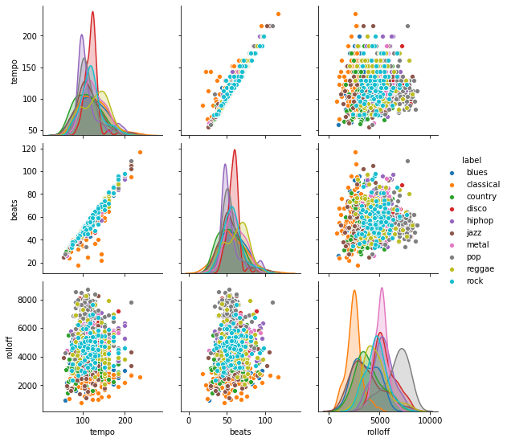

```python
#그래프 1.
sns.pairplot(music, hue='label', vars=['tempo', 'beats', 'rolloff'])

#장르별로 분류
```

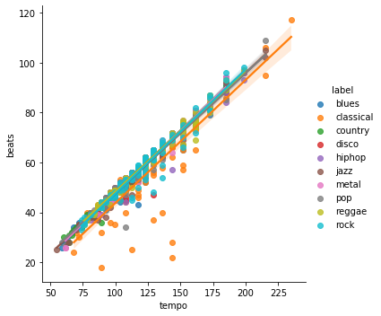

```python
# 그래프2.
sns.lmplot(x = 'tempo',hue='label', y = 'beats', data = music)
```

```python
#음악은 비트가 빨라질수록, 대체적으로 템포가 빨라짐을 알 수 있다.
#그러나, classical 음악(주황색)은 가끔 tempo가 높아도 beats가 낮은 특징을 알 수 있다.
#비트 = 드럼으로 연주하는 패턴(==타악기 등으로 주기적으로 음을 끊는것)
#템포 = 패턴이 연주되는 속도 (= Beat per Minute) 으로도 표현되는데, 클래식 음악의 특징상
#타악기(=드럼)과 같은 악기의 일정한 패턴은 느리기 때문에, tempo가 높다하더라도 beat는 낮은 경우를 볼 수 있다.
```

## 교차검증을 통해 KNN,SVM,RF,Decision Tree 중 어떤게 Best인지 확인

```python
from sklearn.model_selection import cross_val_score #CV Cross Validation 교차검증 방법
from sklearn.svm import SVC #서포트 백터머신 임포트
```

### 1. SVM

```python
svc = SVC()
```

```python
svc.fit(x_train, y_train) #훈련
```

```
SVC(C=1.0, break_ties=False, cache_size=200, class_weight=None, coef0=0.0,
    decision_function_shape='ovr', degree=3, gamma='scale', kernel='rbf',
    max_iter=-1, probability=False, random_state=None, shrinking=True,
    tol=0.001, verbose=False)
```

```python
scores_svc = cross_val_score(svc, x_train, y_train, cv = 10)
```

```python
scores_svc # SVC 모델로 train data 가 들어왔을때, 각 label에 맞는 정답 정확도 결과
```

```
array([0.35  , 0.3   , 0.3   , 0.325 , 0.3   , 0.325 , 0.35  , 0.325 ,
       0.25  , 0.2875])
```

```python
scores_svc.mean() #SVC 모델 평균 정확도 결과
```

```
0.31125
```

### 2. KNN

```python
from sklearn.neighbors import KNeighborsClassifier
```

```python
knn = KNeighborsClassifier(n_neighbors=3) #최근접 이웃방식으로 모델 예측, 주위 3개까지 가져옴! 홀수만
```

```python
knn.fit(x_train, y_train) #train 데이터로 y데이터를 예측해보아라
```

```
KNeighborsClassifier(algorithm='auto', leaf_size=30, metric='minkowski',
                     metric_params=None, n_jobs=None, n_neighbors=3, p=2,
                     weights='uniform')
```

```python
scores_knn = cross_val_score(knn, x_train, y_train, cv= 10)
```

```python
scores_knn #KNN 모델로 train data 가 들어왔을때, 각 label에 맞는 정답 정확도 예측
```

```
array([0.2375, 0.325 , 0.25  , 0.3875, 0.3875, 0.3375, 0.3   , 0.4   ,
       0.3625, 0.375 ])
```

```python
scores_knn.mean() #KNN 모델 평균 정확도 결과
```

```
0.33625
```

## 3. Decision Tree

```python
from sklearn.tree import DecisionTreeClassifier
```

```python
tree_clf = DecisionTreeClassifier(max_depth=8, random_state=13) #Decsion Tree
```

```python
tree_clf.fit(x_train, y_train) #디씨션 트리로 학습
print('Scroe :', format(tree_clf.score(x_train,y_train))) #트리 정확도는 0.723
```

```
Scroe : 0.72375
```

```python
scores_tree = cross_val_score(tree_clf, x_train, y_train, cv= 10) #교차검증 10개 하였을때?
```

```python
scores_tree
```

```
array([0.475 , 0.45  , 0.425 , 0.4   , 0.45  , 0.45  , 0.4125, 0.4125,
       0.4125, 0.4375])
```

```python
scores_tree.mean() #트리모델 정답 평균
```

```
0.4325
```

## 4. Random Forest

```python
from sklearn.ensemble import RandomForestClassifier
```

```python
clf_rf = RandomForestClassifier()
```

```python
clf_rf.fit(x_train,y_train)
```

```
RandomForestClassifier(bootstrap=True, ccp_alpha=0.0, class_weight=None,
                       criterion='gini', max_depth=None, max_features='auto',
                       max_leaf_nodes=None, max_samples=None,
                       min_impurity_decrease=0.0, min_impurity_split=None,
                       min_samples_leaf=1, min_samples_split=2,
                       min_weight_fraction_leaf=0.0, n_estimators=100,
                       n_jobs=None, oob_score=False, random_state=None,
                       verbose=0, warm_start=False)
```

```python
scores_rf = cross_val_score(clf_rf, x_train, y_train, cv= 10) #교차검증 10개 하였을때?
```

```python
scores_rf
```

```
array([0.5875, 0.5375, 0.4875, 0.4875, 0.5625, 0.5625, 0.4875, 0.5125,
       0.55  , 0.5   ])
```

```python
scores_rf.mean() #RF 모델
```

```
0.5275
```

#### CV=10 으로 하였을땐, RF 모델이 제일 분류화 예측을 잘하는 것 같다.

## 5. Grid Search를 활용하여 분류 최적화 방법 선정

```python
from sklearn.model_selection import KFold, GridSearchCV
```

```python
kfold = KFold(n_splits=5, shuffle=True, random_state=0) # n_splits 는 데이터 분할 수 입니다. 전체 데이터 수를 넘을 수 없습니다.
```

```python
values = [0.0001, 0.01, 0.1, 1, 10, 100] #c, gamma 를 하이퍼 파라미터로 조정 할 예정, values(list) 만큼
```

```python
#RBF 또는 Linear
#RBF 방법과 Linear 방법 둘 다 씀, Kernel 은 프로그래밍의 핵심!, C와 Gamma 에 Values 의 리스트를 넣어, 6x6 방식만큼 경우의 수로
#트레인 데이터 샘플을 나누어 학습하겠다.

param_grid = [
    {'kernel' : ['rbf'], 'C':values, 'gamma' : values},
    {'kernel' : ['linear'], 'C': values }
]
```

```python
grid_search_svc = GridSearchCV(svc, param_grid, cv=kfold) #cv= Cross_validation는 K-Fold 방식(데이터를 분할한것)
```

## K-fold 방식과 Grid Search를 활용하여, svc 모델의 하이퍼 파라미터를 재조정하고

## 정확도를 최적화해봄

```python
grid_search_svc
```

```
GridSearchCV(cv=KFold(n_splits=5, random_state=0, shuffle=True),
             error_score=nan,
             estimator=SVC(C=1.0, break_ties=False, cache_size=200,
                           class_weight=None, coef0=0.0,
                           decision_function_shape='ovr', degree=3,
                           gamma='scale', kernel='rbf', max_iter=-1,
                           probability=False, random_state=None, shrinking=True,
                           tol=0.001, verbose=False),
             iid='deprecated', n_jobs=None,
             param_grid=[{'C': [0.0001, 0.01, 0.1, 1, 10, 100],
                          'gamma': [0.0001, 0.01, 0.1, 1, 10, 100],
                          'kernel': ['rbf']},
                         {'C': [0.0001, 0.01, 0.1, 1, 10, 100],
                          'kernel': ['linear']}],
             pre_dispatch='2*n_jobs', refit=True, return_train_score=False,
             scoring=None, verbose=0)
```

```python
# grid_search_svc.fit(x_train, y_train)
#grid_search_svc 는 하이퍼 파라미터가 재 조정된 모델 / 재학습
#gird_search 해당 모델은 너무 오래걸려서 중지함
```